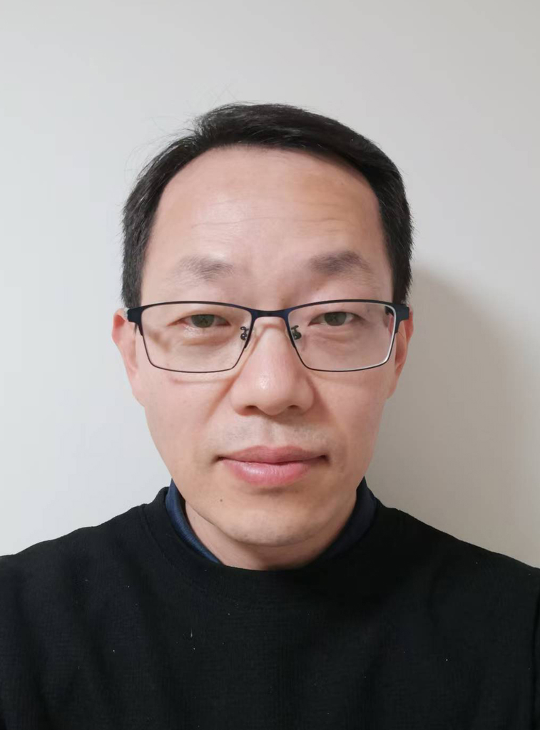

# Wu Kang/吴康

I completed both my Bachelor’s and Master’s degrees in Biotechnology through a combined program/本硕连读 at Northwest A&F University, followed by a Ph.D. in Biochemistry and Molecular Biology from Shanghai Jiao Tong University. From 2012 to 2021, I worked as a Research Assistant at Shanghai Public Health Clinical Center (affiliated with Fudan University), focusing on tuberculosis immunology, vaccine development, and bioinformatics.

After transitioning from academia to industry, I have continued to pursue advancements in omics- and cell-relevant technologies, particularly in therapeutic and diagnostic applications. I trust that I can follow in the footsteps of individuals like 2024 Nobel Prize laureate John M. Jumper, who made an impressive transition to industry after his Ph.D. graduation—haha.

I am self-taught in R and am continually enhancing my bioinformatics skills, including Bash and Python (my hobby too-haha).

You can view my (co-)first author articles, and the research projects I’ve led, from my “ORCID”. My full resumé, a mix of Chinese and English, is available from the “Resumé/简历”.